# Homework 4 Solutions

### Question 1 (3 pts)

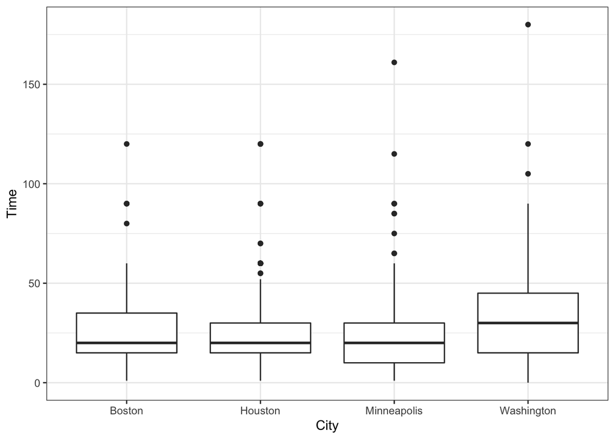

```r
MetroCommutes %>%
  ggplot(aes(x = City, y = Time)) +
  geom_boxplot() +
  theme_bw()
```

**Grading:** 1 pt for plot, 1 pt for describing boxplots, 1 pt for comparing between cities.

### Question 2 (1 pt)

```r
MetroCommutes %>%
  count(City)
```

```
##          City   n
## 1      Boston 500
## 2     Houston 500
## 3 Minneapolis 500
## 4  Washington 500
```

We have 500 observations in each city.

**Grading:** They can get the numbers different ways. They just need to report 500 in each city.

### Question 3 (3 pts)

$$\text{Time} = \beta_0 + \beta_1 \text{IsHouston} + \beta_2 \text{IsMinnneapolis} + \beta_3 \text{IsWashington} + \varepsilon$$
There are 4 parameters ( $\beta_0$, $\beta_1$, $\beta_2$, and $\beta_3$ ).

**Grading:** 2 pts for population model, 1 pt for number of parameters

- Lose 1 pt if they don’t make Boston the base category
- Lose 1 pt if they don’t include $\varepsilon$
- Lose 1 pt if they don’t use indicator variables (e.g. if they do $\beta_2 \text{City}$ )

### Question 4 (4 pts)

```r
city_lm <- lm(Time ~ City, data = MetroCommutes)
summary(city_lm)
```

```
##
## Call:
## lm(formula = Time ~ City, data = MetroCommutes)
##
## Residuals:
##     Min      1Q  Median      3Q     Max
## -31.690 -12.742  -2.742   8.310 148.310
##
## Coefficients:
##                 Estimate Std. Error t value Pr(>|t|)
## (Intercept)      25.7460     0.8207  31.372  < 2e-16 ***
## CityHouston      -0.6480     1.1606  -0.558  0.57668
## CityMinneapolis  -3.0040     1.1606  -2.588  0.00972 **
## CityWashington    5.9440     1.1606   5.121 3.32e-07 ***
## ---
## Signif. codes:  0 '***' 0.001 '**' 0.01 '*' 0.05 '.' 0.1 ' ' 1
##
## Residual standard error: 18.35 on 1996 degrees of freedom
## Multiple R-squared:  0.03132,    Adjusted R-squared:  0.02986
## F-statistic: 21.51 on 3 and 1996 DF,  p-value: 1.037e-13
```

$$\widehat{\text{Time}} = 25.746 - 0.648 \ \text{IsHouston} - 3.004 \ \text{IsMinnneapolis} + 5.944 \ \text{IsWashington}$$
Average commute times in each city:

- Boston: 25.746
- Houston: 25.746 - 0.648 = 25.098
- Minneapolis: 25.746 - 3.004 = 22.742
- Washington: 25.746 + 5.944 = 31.69

**Grading:** 2 pts for equation of fitted model, 2 pts for mean in each city

- Lose 1 pt if they don’t put hat on the response, and/or if they add hats to the predictors, and/or if they keep $\varepsilon$ in the equation
- Lose 1 pt if they think the estimated coefficients on the cities are the means (e.g., they report that -0.648 is the mean for Houston)

### Question 5 (4 pts)

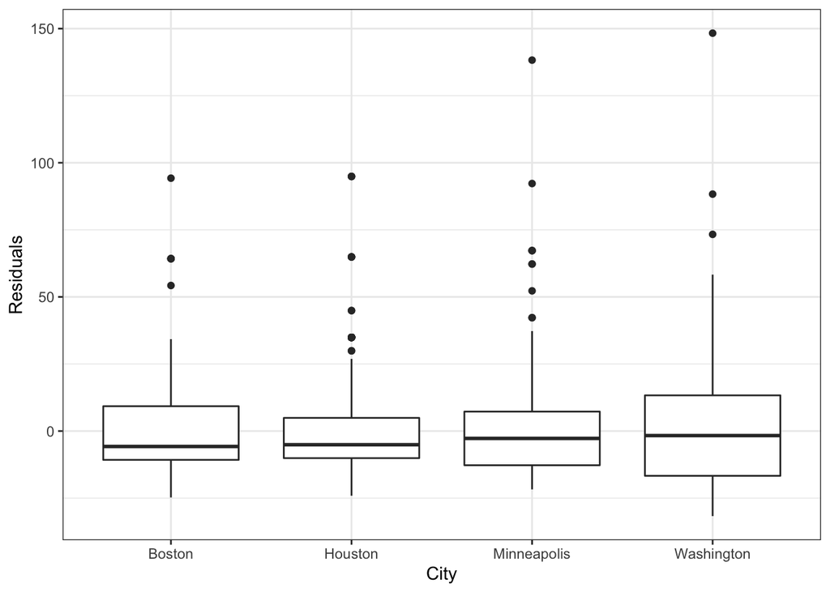

```r
MetroCommutes %>%
  mutate(resids = residuals(city_lm)) %>%
  ggplot(aes(x = City, y = resids)) +
  geom_boxplot() +
  theme_bw() +
  labs(x = "City",
       y = "Residuals")
```

```r
MetroCommutes %>%
  mutate(resids = residuals(city_lm)) %>%
  group_by(City) %>%
  summarize(residual_std_dev = sd(resids))
```

```
## # A tibble: 4 × 2
##   City        residual_std_dev
##   <fct>                  <dbl>
## 1 Boston                  17.6
## 2 Houston                 17.5
## 3 Minneapolis             16.9
## 4 Washington              21.2
```

**Grading:** 1 pt for plot, 1 pt for standard deviations, 1 pt for calculating ratio, 1 pt for conclusion

### Question 6 (2 pts)

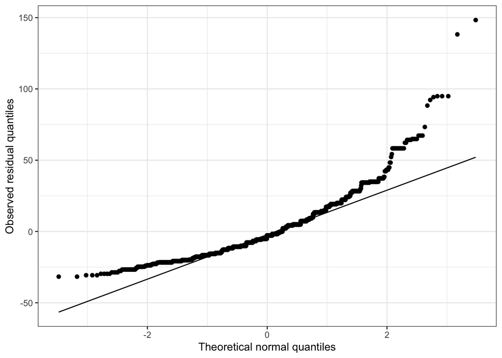

```r
MetroCommutes %>%
  mutate(resids = residuals(city_lm)) %>%
  ggplot(aes(sample = resids)) +
  geom_qq() +
  geom_qq_line() +
  theme_bw() +
  labs(x = "Theoretical normal quantiles",
       y = "Observed residual quantiles")
```

The normality assumption appears to be violated here – there is some deviation from normality in the tails, particularly the right tail.

**Grading:** 1 pt for plot, 1 pt for interpretation

### Question 7 (4 pts)

```r
city_lm <- lm(sqrt(Time) ~ City, data = MetroCommutes)
summary(city_lm)
```

```
##
## Call:
## lm(formula = sqrt(Time) ~ City, data = MetroCommutes)
##
## Residuals:
##     Min      1Q  Median      3Q     Max
## -5.3207 -1.2948 -0.0164  1.0039  8.2000
##
## Coefficients:
##                 Estimate Std. Error t value Pr(>|t|)
## (Intercept)      4.75892    0.07688  61.902  < 2e-16 ***
## CityHouston     -0.02867    0.10872  -0.264    0.792
## CityMinneapolis -0.27037    0.10872  -2.487    0.013 *
## CityWashington   0.56174    0.10872   5.167 2.62e-07 ***
## ---
## Signif. codes:  0 '***' 0.001 '**' 0.01 '*' 0.05 '.' 0.1 ' ' 1
##
## Residual standard error: 1.719 on 1996 degrees of freedom
## Multiple R-squared:  0.03059,    Adjusted R-squared:  0.02913
## F-statistic: 20.99 on 3 and 1996 DF,  p-value: 2.174e-13
```

$$\widehat{\sqrt{\text{Time}}} = 4.759 - 0.029 \ \text{IsHouston} - 0.270 \ \text{IsMinnneapolis} + 0.562 \ \text{IsWashington}$$

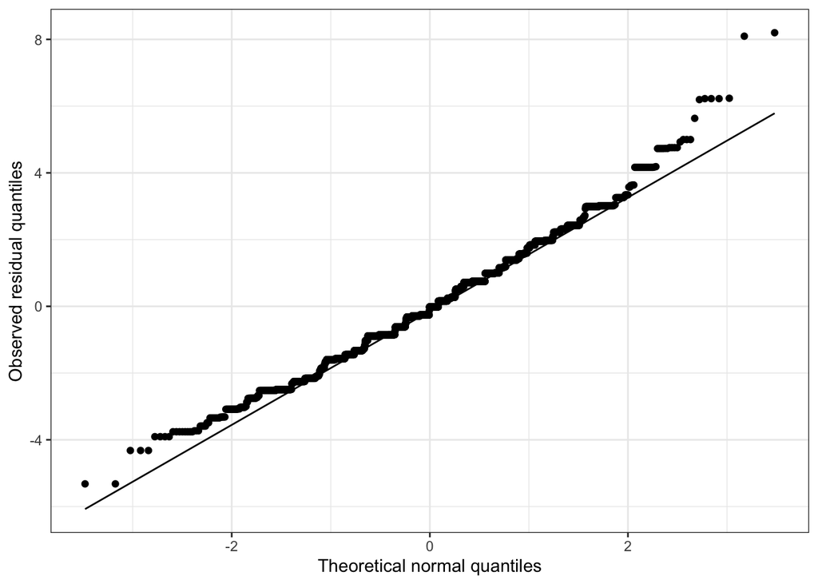

```r
MetroCommutes %>%
  mutate(resids = residuals(city_lm)) %>%
  ggplot(aes(sample = resids)) +
  geom_qq() +
  geom_qq_line() +
  theme_bw() +
  labs(x = "Theoretical normal quantiles",
       y = "Observed residual quantiles")
```

The normality assumption looks much better now. It still isn’t perfect (there is a little deviation in the right tail), but it looks pretty good.

**Grading:** 2 pts for equation of fitted line, 1 pt for new plot, 1 pt for interpretation

- Lose 1 pt if they don’t put hat on the response, and/or if they add hats to the predictors, and/or if they keep $\varepsilon$ in the equation, and/or if they don’t square root time in the equation

### Question 8 (3 pts)

$H_0: \beta_1 = \beta_2 = \beta_3 = 0$

$H_A: \text{at least one of } \beta_1, \beta_2, \beta_3 \neq 0$

**Grading:**

- Lose 1 pt if they include $\beta_0$ in the hypotheses
- Lose 1 pt if they don’t correctly negate the null for $H_A$ (e.g., if they say all of them are not 0)
- Lose 1 pt if they don’t write the hypotheses in terms of the parameters

### Question 9 (4 pts)

```r
anova(city_lm)
```

```
## Analysis of Variance Table
##
## Response: sqrt(Time)
##             Df Sum Sq Mean Sq F value    Pr(>F)
## City         3  186.1  62.038  20.993 2.174e-13 ***
## Residuals 1996 5898.5   2.955
## ---
## Signif. codes:  0 '***' 0.001 '**' 0.01 '*' 0.05 '.' 0.1 ' ' 1
```

Test statistic: 20.993

Degrees of freedom: 3 and 1996

p-value: $2.17 \times 10^{-13}$

Conclusion: we have strong evidence for a difference in mean commute times between the different cities

**Grading:** 1 pt for test statistic, 1 pt for degrees of freedom, 1 pt for p-value, 1 pt for conclusion